# NCB獸醫小讀書會

實驗動物科學 - 基礎篇 (P205-240)

陳敬元 Jing-Yuan Chen, DVM, PhD

jychen@niar.org.tw

國家生物模式中心 (National Center for Biomodels)  
國家實驗研究院 (National Institute of Applied Research)

July 7, 2026

# 第一部分：前言與統計視覺化迷思

## 為什麼需要動物實驗設計？

- **推動醫學的關鍵**：執行動物實驗的目的是希望驗證科學假說，或測試新藥與療法的效果及安全性。
- **避免資源浪費**：不準確的結果將導致錯誤結論，浪費研發資源投入開發錯誤或危險的療法。
- **實踐 3R 精神**：透過取代 (replacement)、減量 (reduction) 與精緻化 (refinement)，盡可能最小化動物數量。

## 統計學在實驗設計中的角色

- 統計學不單指分析工具，更包含如何觀測紀錄、數據適用性及呈現方式。
- **客觀決策依據**：提供量化的信心指標，讓科學家依據可靠的結果得出客觀結論。
- **潛在危機**：若未仔細調查所有實驗資訊，即使使用了正確的圖表與統計工具，仍可能得出錯誤結論。

## 案例一：降血脂藥 A 的 HDL 迷思 (1/2)

- **情境**：藥廠想檢驗新化合物 A 對降低小鼠高密度脂蛋白 (HDL) 膽固醇的效果。
- **表面數據**：單看長條圖 (Mean±SEM)，藥物 A 組看似 HDL 較低，但未達統計顯著 (*p* = 0.191)。

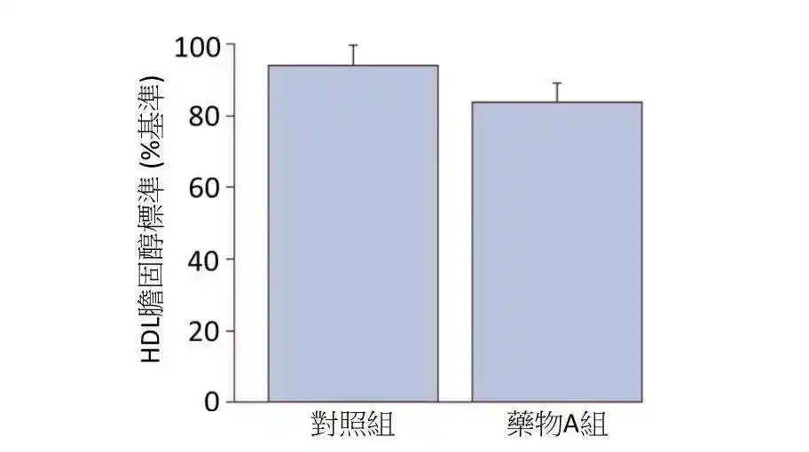

HDL變化百分比(終端/基礎/100)

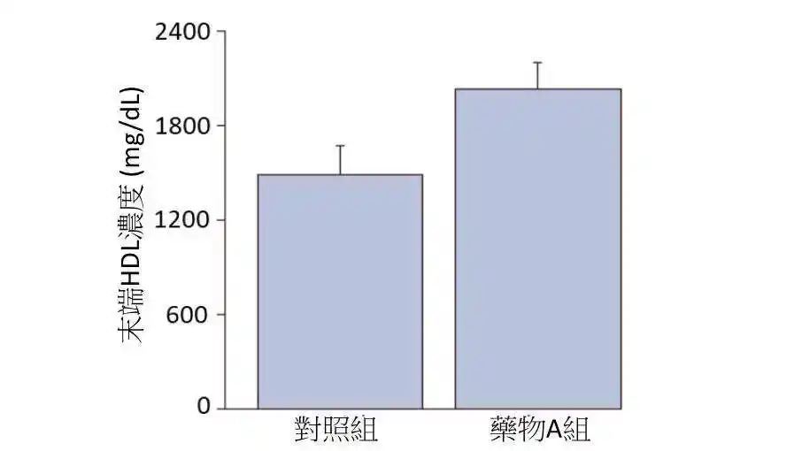

終端HDL數值

## 案例一：降血脂藥 A 的 HDL 迷思 (2/2)

- **原因**：將基礎與終末濃度改為散布圖後，發現分配到「藥物 A 組」的小鼠，其基礎 HDL 濃度原本就偏高。
- **結論**：這是因為當初隨機分組時發生了極端偏見的選擇(分配失衡)，導致結論偏差。
- **解方**：若確定是由分配失衡導致，可依據基礎濃度進行隨機化處理。

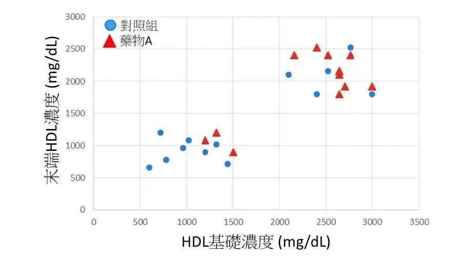

**Note**

**這張圖還是看不出對應關係**

## 案例二：血糖變化的信號與噪音 (1/2)

- **情境**：評估藥物 A 與 B 對糖尿病小鼠血糖的影響，兩者對照組血糖約為 285 mg/dL。
- **表面錯覺**：投予藥物 A 後血糖降至 225 mg/dL；藥物 B 降至 185 mg/dL，只看平均值似乎藥物 B 更有效。

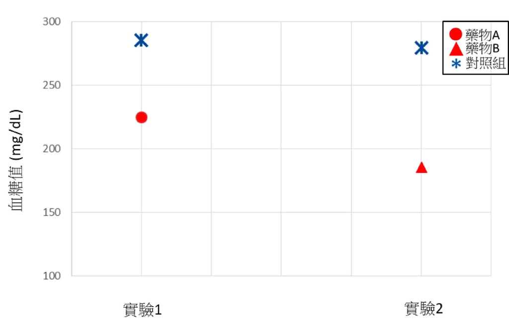

## 案例二：血糖變化的信號與噪音 (2/2)

- **結論反轉**：散布圖顯示藥物 B 變異極大，而藥物 A 變異極小(可能因操作穩定或遺傳背景一致)。
- 因此藥物 A 反而具有更穩定的降血糖療效。

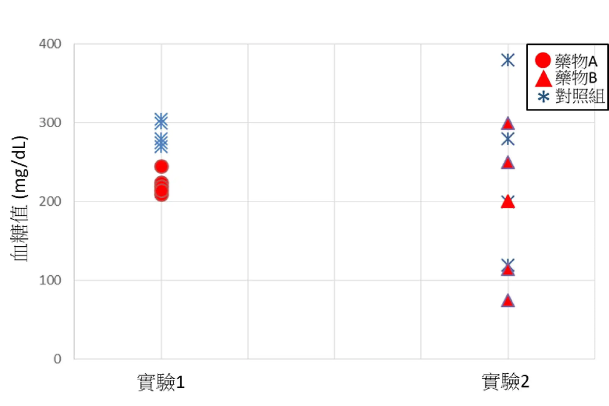

## 信噪比 (Signal-to-Noise Ratio)

- **信號 (分子)**：生物效應的大小；效應越大，信噪比越大。
- **噪音 (分母)**：背景變異性的干擾；變異性越小，信噪比越大。
- **生活比喻**：就像在演講時警報器響起，你可以選擇大聲說話(增加信號)，或關閉警報/門窗(降低噪音)。

# 第二部分：假設檢定、*P* 值與統計檢定力

## 假設檢定的基本概念

- **虛無假說 ($H_0$)**：假設實驗組與控制組的平均存活日數等測量反應並無差異。
- **對立假說 ($H_1$)**：假設反應受到新處理的影響，兩組平均值不相等。
- **原則**：統計檢定先假設 $H_0$ 成立；若證據不足以拒絕 $H_0$，也不代表 $H_0$ 一定為真。

## $p$ 值的真實意義

- $p$ 值是由英國統計學家 R.A. Fisher 所提出。
- **意義**：在「假定虛無假說為真」的前提下，觀察到檢定統計量得到極端值(純粹靠運氣)的機率。
- ❌ **迷思**：$p$ 值越小 ($<0.001$)，並不代表實驗反應的效果越強。
- ✔️ **真相**：$p$ 值僅應用於判斷顯著與否的臨界值，無法直接推斷反應效果的強弱。

## 顯著標準 (Significance Level)

- 顯著水準通常設定為 $\alpha = 0.05$，作為是否拒絕虛無假說的判斷門檻。
- 若 $p < 0.05$，代表在 $H_0$ 為真的假設下，目前這麼極端或更極端的結果不太常見。
- 因此研究者會拒絕 $H_0$，稱為達到統計顯著。

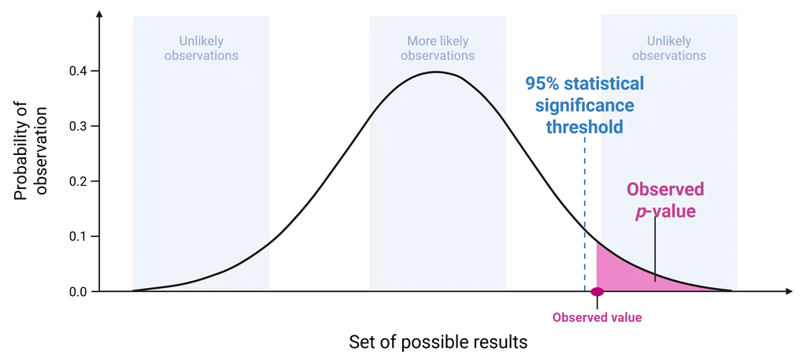

## 統計判斷的兩種錯誤

|  | 拒絕 $H_0$ (宣稱有差異) | 未拒絕 $H_0$ (未宣稱有差異) |
| --- | --- | --- |
| **$H_0$ 真** (無差異) | **第一型錯誤 (Type I)** | 正確判斷 I |
| **$H_0$ 非** (有差異) | 正確判斷 II (Power) | **第二型錯誤 (Type II)** |

- **第一型錯誤 (Type I / 偽陽性)**：明明無罪的人卻被冤枉判刑。
- **第二型錯誤 (Type II / 偽陰性)**：健檢沒驗出癌症標記，結果不久後員工因大腸癌過世(漏診)。

## The boy cried for wolf

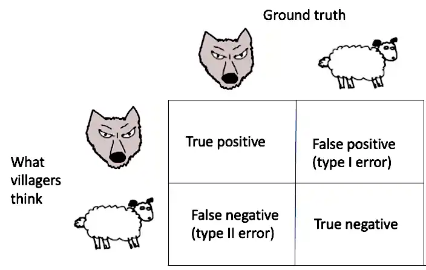

## 統計檢定力 (Statistical Power)

- **公式**：`Statistical Power = 1 - β` (β = Type II error probability)。
- 在樣本數與效果大小固定時，若要求降低第一型錯誤風險，條件會變嚴格，第二型錯誤風險可能增加。
- **提高檢定力**：增加動物隻數 (n, 樣本數)，可降低標準誤，使抽樣分佈變窄，減少第二型錯誤 ($\beta$)。
  - 或是，真實效果大小較大時，$H_0$ 與 $H_1$ 的分佈分離更明顯，檢定力也會提高。

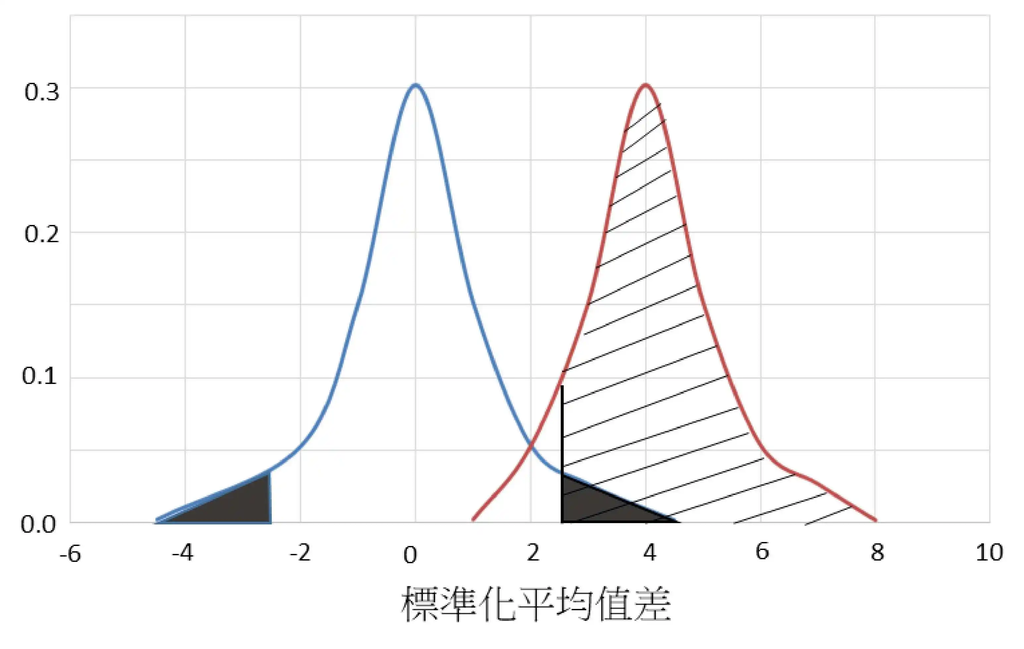

## $\alpha$、$\beta$、effect size 與 power

[figure not shown]

## 探索型與求證型實驗

- **探索型 (Exploratory)**：測試未知因子以「建立假說」；為避免錯失機會，起初不需嚴格多重比較校正，極易產生偽陽性。
- **求證型 (Confirmatory)**：驗證特定先驗假說，需妥善安排統計策略並進行校正，以降低偽陽性的機會。

## 案例：基因轉殖迷你豬 MRI

- **探索階段**：研究者比較基因轉殖與野生型迷你豬的大腦，利用 MRI 全面檢視是否有腦區體積變化的表現型，這是一種可能產生偽陽性的探索。
- **求證階段**：一旦探索到特定結果，就進一步設計嚴謹的求證型實驗，專門檢驗特定腦區是否受影響。

# 第三部分：實驗設計的實務與反應變項

## 實驗設計的三大目標

1. **減少變異性 (Noise)**：透過設計(如區集)控制會導致變異性的干擾因子。
2. **增加信號強度 (Signal)**：例如評估發炎反應時，選擇最敏感的 DBA 或 BALB/c 小鼠品系進行實驗。
3. **減少偏差 (Bias)**：確保減少與對照組比較時發生已知或未知的潛在干擾。

## 案例三：致命的隨機偏差與區集控制

- **錯誤示範**：非隨機地把「最老」的動物放在對照組，把「最年輕」的放在處理組；結果將無法辨識是藥效還是年齡造成的差異。
- **區集應用**：在評估尼古丁刺激成癮行為 (CPP trial) 實驗中，保證 4 個處理組的環境喜好測試箱「完全一樣」，排除測試箱的偏差效應。

## 實驗變數的記錄

- **紀錄變數**：在規劃與執行實驗時，除了記錄「反應」，也應該記錄「體重、飼育籠位置、健康狀況、操作員」等干擾變數，協助日後除錯。
- 選定的量測「反應 (response)」應該要有生物效應意義，並選擇能最大化信噪比的反應變項資料型態。

## 五種常見的結果變項型態

- **連續型變項 (Continuous)**：可用連續數值測量，例如體重 7.0 g 或 7.5 g；資訊量較高，較小樣本數也可能有足夠敏感度。
- **離散／計數型變項 (Discrete / Count)**：以整數計數，例如四肢關節炎評分加總 0-16；若數值範圍很大，有時可近似連續型處理。
- **順序型變項 (Ordinal)**：有等級順序，但等級間距不一定相等，例如疾病輕度／中度／重度。
- **名目型變項 (Nominal)**：類別之間沒有大小或順序，例如注射後不同的迫切行為表現類型。
- **二元型變項 (Binary)**：只有兩種結果，例如是／否、存活／死亡；資訊量較少，通常需要較大樣本數。

## 案例：普拿疼對腎臟的傷害量測

- 量測普拿疼對大鼠腎臟的影響，可採用不同方式：
  1. **連續型**：量測整個腎臟切片所有受傷區域 (最耗時，資訊最多)。
  2. **順序型**：針對切片評分 (輕度、中度、重度)。
  3. **二元型**：只記錄切片內「有」或「沒有」傷害 (省時，但需要超大樣本數來彌補敏感度)。

## 沒有對照組，實驗毫無價值

- 沒有對照組就不可能下任何結論，因為幾乎所有實驗結論都取決於與對照組的比較。
- **陰性對照 (Negative)**：確保某個未知變數不會影響實驗結果，減少偽陽性。
- **空白對照 (Vehicle)**：使用試驗溶劑或媒介物，確認反應非媒介物引起。

## 其他常見對照組

- **陽性對照 (Positive)**：用來證明實驗系統有能力觀測到已知的處理效應。
- **安慰劑對照 (Placebo)**：外觀或流程類似實驗處理，但不含有效成分，用來控制期待效果與非特異性處理影響。
- **偽對照／模擬對照 (Sham)**：用於區分「手術創傷」與「植入醫材」的效應。
- **對比對照 (Comparative)**：將新療效與傳統療法進行比較。
- **未處理對照／原始對照 (Naive / Untreated)**：什麼處理都不做，確認動物基本狀態。

# 第四部分：單元、因子與實驗模型

## 實驗單元 vs 觀測單元

- **實驗單元 (Experimental unit)**：實驗中能獨立接受不同處理的「最小單位」。
- **觀測單元 (Observational unit)**：實驗中用來量測反應的最小單位。
- **案例區分**：若一整籠魚共用水裡的藥物，「魚缸」才是實驗單元；若從小鼠取出器官進行多個切片檢查，小鼠是實驗單元，切片為觀測單元。

## 效應與因子的屬性

- **固定因子 (Fixed)**：結論僅限於指定的層次間。例如挑選 A 房間與 B 房間的猴子做比較，結論僅限於 A 與 B。
- **隨機因子 (Random)**：從母體隨機抽樣，結論可推論至整體。例如隨機挑選 10 間房，用以推論整個動物設施的變異趨勢。

## 因子的交疊關係：巢套與交叉

- **巢套因子 (Nested)**：一個因子的層次被包含在另一個層次之下(例如對照組專屬動物編號 6-10，這些動物不會接受別種處理)。

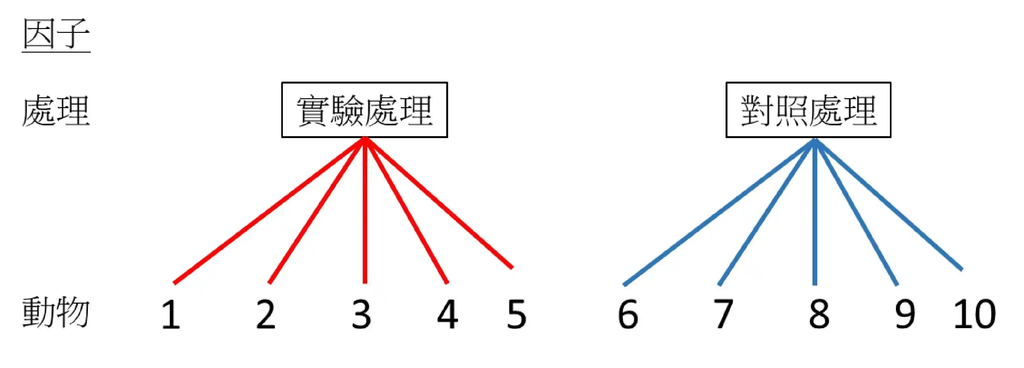

- **交叉因子 (Crossed)**：所有處理與動物間皆能完整對應(例如每隻動物都會接受所有的處理層次)。

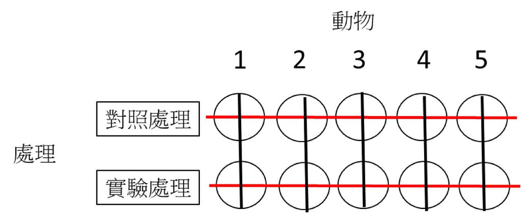

## 區集設計：先分區集，再在區集內隨機

- **區集 (block)**：已知會影響結果、但不是主要研究問題的干擾因素。
- **目的**：讓每個處理組在每個區集內都有代表，避免處理效果和區集效果混在一起。

| 操作日期 | 錯誤安排 | 區集設計 |
| --- | --- | --- |
| Day 1 | 全部對照組 | 對照、低劑量、高劑量 |
| Day 2 | 全部低劑量 | 對照、低劑量、高劑量 |
| Day 3 | 全部高劑量 | 對照、低劑量、高劑量 |

## 劑量-反應設計：不是只比較有沒有差

- **劑量-反應設計 (Dose-response)**：建立測試物質在不同劑量下產生的線性或非線性反應關係。
- **重點**：用多個劑量組觀察反應趨勢、平台效應或毒性閾值。

Vehicle

→

Low dose

→

Medium dose

→

High dose

反應趨勢：無變化 → 逐漸上升 → 平台效應／毒性閾值

## 實驗設計類型：遞增與重複量測

- **劑量遞增設計 (Dose-escalating)**：通常非隨機，動物依序接受由低到高的劑量測試 [32, 33]。
- **重複量測設計 (Repeated measures)**：在同一實驗單元的不同時間點重複量測，時間因子無法隨機分派。
- 實務上往往混合多種設計 (例如：區集交叉設計 Blocked crossover design) 以應對複雜限制。

## 重複量測動物：先判斷資料結構

同一隻動物產生多筆資料時，先問三個問題：

**A. 重複在哪裡？**

時間點、樣本、部位，還是多個 outcome？

→

**B. 處理在哪一層？**

動物間、動物內，或兩者都有？

→

**C. 順序能隨機嗎？**

可隨機為 crossover；不可隨機常見於 dose-escalation。

重點：不要把同一隻動物內的多筆資料，誤當成彼此獨立的多隻動物。

## 同一隻動物有多筆資料：重複在哪裡？

1. **重複量測 (Repeated measures)**：同一隻動物在不同時間點或條件下反覆量測。  
   例：每隻小鼠在 day 0、7、14、21 量體重或血糖。
2. **動物內樣本／部位巢套 (Samples nested within animal)**：多個樣本來自同一隻動物，因此彼此不獨立。  
   例：每隻動物取 3 個組織切片、數個視野，或多個細胞樣本。
3. **多個 outcome**：同一隻動物同時量多種結果變項。  
   例：體重、器官重量、血液生化值、組織評分。

## 處理放在動物體內不同位置：處理在哪一層？

當處理是在同一隻動物的不同部位進行時，設計層級會改變：

4. **動物作為區集 (Animal as block)**
- 同一隻動物內的不同位置接受不同處理。
- 例：同一隻動物背部不同皮膚區域，隨機塗抹 vehicle、低劑量、高劑量藥物。
5. **裂區設計 (Split-plot design)**
- 有些因子在「動物間」分配，有些因子在「動物內」分配。
- 例：兔子分成不同犧牲時間點；每隻兔子體內再隨機植入不同醫材。

## 同一動物跨時間接受處理：順序能隨機嗎？

6. **交叉設計 (Crossover design)**
- 同一隻動物在不同期間接受不同處理，且順序可隨機安排。
- 例：每隻動物依隨機順序接受不同飼料或環境條件，中間設 washout period。
7. **劑量遞增設計 (Dose-escalation)**
- 同一隻動物隨時間接受不同劑量，但順序通常不能隨機。
- 例：毒性或安全性試驗中，劑量由低到高逐步增加。

## 總結：優秀實驗設計的 5 大特徵

1. **減少系統性誤差**：減少處理的偏差，不用擔心任何非預期的干擾對實驗結果造成影響。
2. **增加實驗結論的適用範圍**：例如同時採用雌性和雄性動物，不僅限單一性別，增加結論的普適性。
3. **簡潔有力**：越直觀簡潔越好，除非必要，否則不要納入過多變數導致複雜化。
4. **分析方法明確**：在規劃實驗的階段，就該完成並確定好資料的統計方式，不該得到數據後才決定。
5. **對實驗變異性的估測可靠**：如果能有效評估並且減低實驗數據的變異性，我們就可以減少動物的使用量，完全符合 3R 的實驗精神！